# Цель ноутбука

Получить аналитически выражения для ROC-кривых и построить их для различных значений отношения сигнал-шум, предполагая, что X имеет данные распределения.

# 1. Постановка задачи

Рассматривается радиолокационная станция (РЛС). РЛС посылает импульсы, которые отражаются от объектов. Отражённый сигнал $X$ воспринимается приёмной антенной радара (Рис. 1). Если есть какой-либо объект, находящийся в зоне обнаружения (ЗО)$^1$, то отраженный сигнал будет выше порога детектирования $λ$ и это будет означать наличие объекта $(D_1)$. Если отражённый сигнал ниже порога детектирования, то это означает отсутствие объекта $(D_0)$.

[figure not shown]

Рис. 1 Поясняющий рисунок!

$^1$ **Зоной обнаружения РЛС** называется область пространства, в пределах которой РЛС обеспечивает обнаружение объектов с вероятностями правильного обнаружения $P_d$ и ложной тревоги $P_{fa}$ не хуже требуемых.

Наличие объекта обозначим как гипотеза $H_1$, а его отсутствие как гипотеза $H_0$. Сигнал $X$ — это случайная величина. Предположим, что мы имеем условные распределения $(1)$, которые известны.

$$f_{(X|H_0)} (x│H_0 ), \ f_{(X|H_1)}(x│H_1)\ \ \ \ (1)$$

Очевидно, что мы можем говорить о том, что $X$ имеет одинаковое распределение для обоих гипотез, но математические ожидания условных распределений $(1)$ будут различными. Так же реалистично предположить, что

$$E[X│H_0]<E[X│H_1]\ \ \ \ (2)$$

Учитывая отклонения X, возникающие из-за шума, получаем:

[figure not shown]

Рис. 2 Условные распределения плотностей (1)

На Рис. 2 $\ η_0, η_1$ — есть условные математические ожидания случайной величины $X$ при условии гипотезы $H_0$ и $H_1$ соответственно. При этом, согласно $(2)$, получаем, что $η_0<η_1$.

Как уже было сказано ранее, сигнал $X$ сравнивается с неким порогом, который мы обозначили как $λ$. Решение о том есть ли объект в ЗО РЛС или нет обозначим как $D_1$ и $D_0$ соответственно. Дополняя Рис. 2 $λ, D_1$ и $D_0$, получаем:

[figure not shown]

Рис. 3 Условные распределения плотностей $(1)$ c обозначением уровня порога $λ$ и диапазонов принятия решений $D_0$ и $D_1$

Получаем следующие условные вероятности:

$$ \begin{array}{l} P_{d}=P\left(D_{1} \mid H_{1}\right)=\int_{D_{1}} f_{X \mid H_{1}}\left(x \mid H_{1}\right) d x \\ P_{f a}=P\left(D_{1} \mid H_{0}\right)=\int_{D_{1}} f_{X \mid H_{0}}\left(x \mid H_{0}\right) d x \end{array} (3) $$

Условные вероятности $(3)$ можно интерпретировать так: $P_d$ – есть вероятность обнаружения объекта при условии, что выполняется гипотеза $H_1$, т.е. объект действительно находится в ЗО.

Визуализируя интегралы $(3)$, получаем:

[figure not shown]

Рис. 4 Вычисление значений $P_d$ и $P_{fa}$ как площади под кривыми $(1)$

Очевидно, что с уменьшением порога $λ$ площадь под кривыми будет больше, а значит, что $P_d$ и $P_{fa}$ будут увеличиваться.

Кривая показывающая зависимость $P_d$ как функцию от $P_{fa}$ для различных $λ$ называется $ROC$-кривая (англ. *Receiver Operating Characteristic*, рабочая характеристика приёмника).

Отклонение случайной величины $X$ определяется характеристикой Отношение сигнал-шум (ОТШ, англ. *Signal-to-Noise Ratio*, сокр. $SNR$), которая записывается как:

$$ S N R=10 \log _{10}\left(\frac{P_{\text {signal }}}{P_{\text {noise }}}\right)[dB] \ \ \ (4) $$

- $P_{signal}$ – мощность сигнала;
- $P_{noise}$ – мощность шума.

Принимая в $(4)$ $P_{signal}=1$, а $P_{signal}=σ^2$ – дисперсия, получаем:

$$ S N R=10 \log _{10}\left(\frac{1}{\sigma^{2}}\right)[d B]\ \ (5) $$

# 2. Построение $ROC$-кривых

**Начальные условия:**

$$ \begin{array}{c} f_{X \mid H_{0}}\left(x \mid H_{0}\right)=\frac{1}{\sqrt{2 \pi \sigma^{2}}} e^{-\frac{x^{2}}{2 \sigma^{2}}} \\ f_{X \mid H_{1}}\left(x \mid H_{1}\right)=\frac{1}{\sqrt{2 \pi \sigma^{2}}} e^{-\frac{(x-1)^{2}}{2 \sigma^{2}}} \end{array} \ \ \ (6) $$$$ S N R \in[-1,5]\ \ \ (7) \\ \lambda \in[0,1]\ \ \ (8) $$

Из $(6)$ видно, что мы делаем предположение о том, что условные плотности имеют нормальное распределение, т.е. $X \mid H_{0} \sim \mathcal{N}\left(0, \sigma^{2}\right)$ и $X \mid H_{1} \sim \mathcal{N}\left(1, \sigma^{2}\right)$, где $\mathcal{N}\left(\mu, \sigma^{2}\right)$ – обозначение нормального распределения с математическим ожиданием $\mu$ и дисперсией $\sigma^{2}$. Ранее мы обозначали $η_0, η_1$ как условное математическое ожидание случайной величины $X$. Исходя из $(6)$, получаем, что $η_0= Ε[X│H_0 ]=0$, а $η_1= Ε[X│H_1 ]=1$.

Из диапазона $(7)$ мы можем понять, какой у нас диапазон дисперсии $\sigma^2$. Для этого выразим из $(5)$ $\sigma$:

$$ \begin{array}{c} S N R=10 \log _{10}\left(\frac{1}{\sigma^{2}}\right)=10 \log _{10}\left(\sigma^{-2}\right)=-2 \cdot 10 \log _{10} \sigma=-20 \log _{10} \sigma \\ -\frac{S N R}{20}=\log _{10} \sigma \\ \sigma=10^{-\frac{S N R}{20}} \ \ (9) \end{array} $$

Подставляя граничные точки отрезка из $(7)$, получаем:

$$ \begin{aligned} &\sigma \in\left[\left.10^{-\frac{S N R}{20}}\right|_{S N R=5},\left.10^{-\frac{S N R}{20}}\right|_{S N R=-1}\right]\\ &\sigma \in\left[10^{-\frac{5}{20}}, 10^{-\frac{-1}{20}}\right]\\ &\sigma \in\left[\sqrt[4]{\frac{1}{10}}, \sqrt[20]{10}\right] \end{aligned} $$

Шаг изменения значений вектора $(11)$ я взял равным $\frac{1}{2}$, т.е. $∆_{SNR}=\frac{1}{2}$. Определим теперь $ROC$-кривую как параметрическую функцию $P_d$ от $P_{fa}$, где в качестве параметра выступает $λ∈[0,1]$. Из $(3)$ и $(6)$, получаем:

$$ \text { ROC }_{\text {curve }}(\sigma, \lambda)=\left\{\begin{array}{r} P_{f a}=\frac{1}{\sqrt{2 \pi \sigma^{2}}} \int_{\lambda}^{+\infty} e^{-\frac{x^{2}}{2 \sigma^{2}}} d x \\ P_{d}=\frac{1}{\sqrt{2 \pi \sigma^{2}}} \int_{\lambda}^{+\infty} e^{-\frac{(x-1)^{2}}{2 \sigma^{2}}} d x \end{array}\right. $$

$\sigma$ – задает конкретную $ROC$-кривую из семейства $ROC$-кривых.

Зададим теперь вектор значений $λ$:

$$ \overrightarrow{\lambda_{\text {values }}}=(0,0.01,0.02, \ldots, 0.98,0.99,1)^{T} $$

Шаг изменения значений вектора $(13)$ я взял равным $\frac{1}{100}$ , т.е. $∆_λ=\frac{1}{100}$. Вектор $(13)$ содержит $101$ значение, т.е. имеем $101$ точек для каждого графика. Таким образом, графики будут визуально выглядеть гладкими.

Имеющихся данных достаточно для построения ROC-кривых.

```python
# подключение дополнительных библиотек
from scipy.stats import norm
from scipy.misc import derivative
import numpy as np
import pandas as pd

import matplotlib.pyplot as plt
import seaborn as sns; sns.set()
%matplotlib inline
```

```python
# зададим вектор SNR и λ
SNR_values = np.arange(-1, 5.5, 1/2)
lambda_values = np.arange(0, 1.01, 1/100)
```

```python
# функция, которая возвращает значение 𝝈 по заданному значению SNR
def snr_to_sigma(SNR):
    return np.power(10, -SNR/20)
```

```python
# функция, которая возвращает значения Pfa и Pd по заданным 𝝈 и λ
def roc_curve(sigma, lambda_):
    return 1 - norm.cdf(lambda_/sigma), 1 - norm.cdf((lambda_ - 1)/sigma)
```

```python
# создание DataFrame в котором будут храниться значения Pfa, Pd, SNR
data = []
for SNR in SNR_values:
    for lambda_ in lambda_values:
        Pfa, Pd = roc_curve(snr_to_sigma(SNR), lambda_)
        data.append([Pfa, Pd, str(SNR)])

data = pd.DataFrame(data, columns=['Pfa', 'Pd', 'SNR'])
```

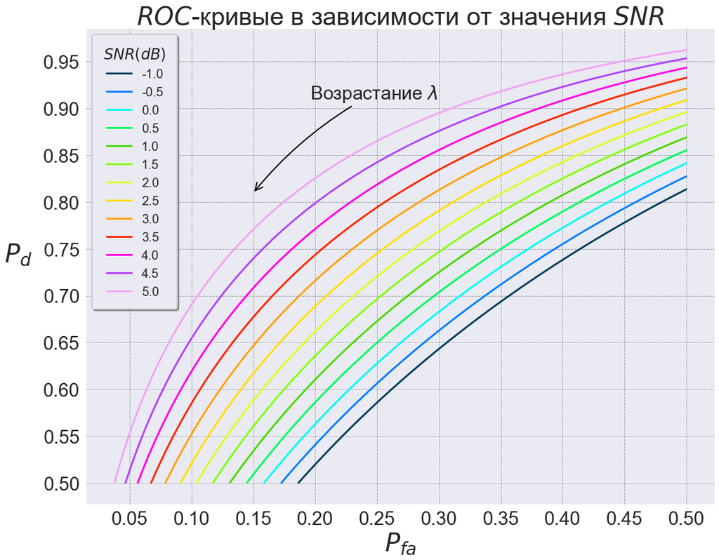

```python
fig, ax = plt.subplots(figsize=(18, 14))
sns.set_context('poster')
plt.title('$ROC$-кривые в зависимости от значения $SNR$', fontsize=40)
plt.xlabel('$P_{fa}$', fontsize=40)
plt.xticks(np.arange(0, 0.7, 0.05), fontsize=30)
plt.yticks(np.arange(0.5, 1, 0.05), fontsize=30)
plt.ylabel('$P_d$', fontsize=40, rotation=0, labelpad=40)
sns.lineplot(x='Pfa', y='Pd', hue='SNR',
             data=data, palette='gist_ncar', ax=ax)

ax.annotate("Возрастание $\lambda$", xy=(0.15, 0.81),  xycoords='data',
            xytext=(90, 150), textcoords='offset points',
            size=30, ha='left',
            arrowprops=dict(arrowstyle="->", color='black',
                            connectionstyle="arc3,rad=0.1"))
plt.grid(color='black', linestyle='--', linewidth=1, alpha=0.3)

plt.legend(fontsize='small', shadow=True, title='$SNR(dB)$',
           borderpad=0.9, fancybox=True);
```

Рис. 5 $ROC$-кривые в зависимости от значения $SNR$.

Из графика видно следующее:

1) Все кривые начинают свое движение с линии $P_{fa}=0.5$ и заканчивают на линии $P_d=0.5$;

2) Чем больше значение $SNR$, тем ближе $ROC$-кривая к точке $(0,1)$;

3) Все кривые выпуклы вверх;

4) $ROC$ - кривая монотонно не убывает. Чем выше лежит кривая, тем лучше качество РЛС.

Первое объясняется ограниченностью значения порога детектирования $(8)$. Посмотрим, как будут выглядеть $ROC$-кривые, если увеличить диапазон $λ$, например, до $[-10,10]$.

```python
# создание DataFrame в котором будут храниться значения Pfa, Pd, SNR
data2 = []
for SNR in SNR_values:
    for lambda_ in np.arange(-10, 10.1, 1/10) :
        Pfa, Pd = roc_curve(snr_to_sigma(SNR), lambda_)
        data2.append([Pfa, Pd, str(SNR)])

data2 = pd.DataFrame(data2, columns=['Pfa', 'Pd', 'SNR'])
```

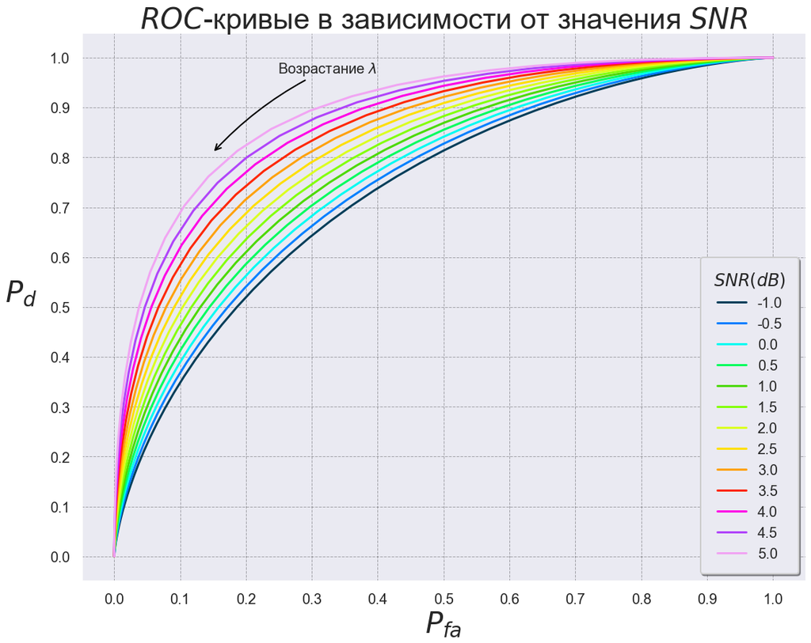

```python
fig, ax = plt.subplots(figsize=(18, 14))
sns.set_context('poster')
plt.title('$ROC$-кривые в зависимости от значения $SNR$', fontsize=40)
plt.xlabel('$P_{fa}$', fontsize=40)
plt.xticks(np.arange(0, 1.05, 0.1), fontsize=20)
plt.yticks(np.arange(0, 1.05, 0.1), fontsize=20)
plt.ylabel('$P_d$', fontsize=40, rotation=0, labelpad=40)
sns.lineplot(x='Pfa', y='Pd', hue='SNR',
             data=data2, palette='gist_ncar', ax=ax)

ax.annotate("Возрастание $\lambda$", xy=(0.15, 0.81),  xycoords='data',
            xytext=(90, 110), textcoords='offset points',
            size=20, ha='left',
            arrowprops=dict(arrowstyle="->", color='black',
                            connectionstyle="arc3,rad=0.1"))
plt.grid(color='black', linestyle='--', linewidth=1, alpha=0.3)

plt.legend(fontsize='small', shadow=True, title='$SNR(dB)$',
           borderpad=0.9, fancybox=True);
```

Рис. 6 $ROC$-кривые в зависимости от значения $SNR$ c увеличенным диапазоном $λ$.

При увеличении диапазона значений, которые может принимать $λ$ получается, что кривые теперь начинают движение с точки $(1,1)$ и заканчивают в точке $(0,0)$. Но стоит уточнить, что кривые только стремятся к данным граничным точкам и достигнут их только при $λ=-∞$ и при $λ=∞$. Это связано с тем, что условные плотности $(6)$ определены на $\mathbb{R}$ и интеграл от них равен $1$ или $0$ тогда и только тогда, когда $λ=-∞$ или $λ=∞$ соответственно.

Второе объясняется тем, что можно достичь большего значения $P_d$ при меньшем значении $P_{fa}$. Это происходит потому, что при увеличении значения $SNR$, уменьшается значение $σ$, что видно из $(9)$. Посмотрим, как визуально изменяются кривые условных плотностей $(6)$ при разных значениях $SNR$.

```python
# функция, которая возвращает значение условных плотностей в зависимости от 𝝈
def conditional_density(x, sigma):
    return norm.pdf(x/sigma), norm.pdf((x - 1)/sigma)
```

```python
# создание DataFrame в котором будут храниться значения условных плотностей и SNR
data3 = []
x_range = np.linspace(-5, 5, 100)
for SNR in SNR_values:
    for x in x_range :
        cond_dens1, cond_dens2 = conditional_density(x, snr_to_sigma(SNR))
        data3.append([cond_dens1, cond_dens2, str(SNR), x])

data3 = pd.DataFrame(data3, columns=['cond_dens1', 'cond_dens2', 'SNR', 'x'])
```

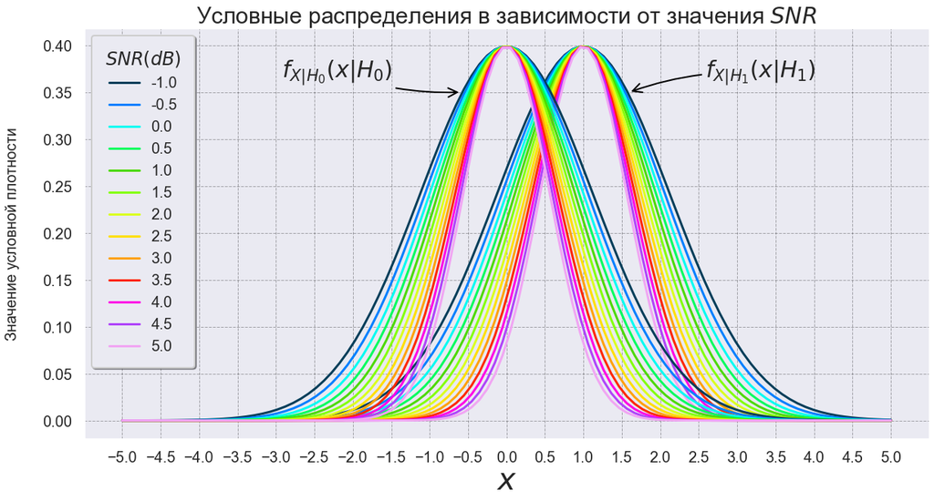

```python
fig, ax = plt.subplots(figsize=(20, 10))
sns.set_context('poster')
plt.title('Условные распределения в зависимости от значения $SNR$',
          fontsize=30)
plt.xlabel('$x$', fontsize=40)
plt.xticks(np.arange(-5, 5.5, 0.5), fontsize=20)
plt.yticks(np.arange(0, 0.45, 0.05), fontsize=20)
plt.ylabel('Значение условной плотности', fontsize=20,
           labelpad=30)

sns.lineplot(x='x', y='cond_dens2', hue='SNR',
             data=data3, palette='gist_ncar', ax=ax)

sns.lineplot(x='x', y='cond_dens1', hue='SNR',
             data=data3, palette='gist_ncar', ax=ax, legend=False)

ax.legend(fontsize='small', shadow=True, title='$SNR(dB)$',
           borderpad=0.9, fancybox=True, loc='upper left')

ax.annotate("$f_{X|H_0}(x|H_0)$", xy=(-0.6, 0.35),  xycoords='data',
            xytext=(-90, 20), textcoords='offset points',
            size=30, ha='right',
            arrowprops=dict(arrowstyle="->", color='black',
                            connectionstyle="arc3,rad=0.1"))

ax.annotate("$f_{X|H_1}(x|H_1)$", xy=(1.6, 0.35),  xycoords='data',
            xytext=(100, 20), textcoords='offset points',
            size=30, ha='left',
            arrowprops=dict(arrowstyle="->", color='black',
                            connectionstyle="arc3,rad=0.1"))

plt.grid(color='black', linestyle='--', linewidth=1, alpha=0.3);
```

Рис. 7 Условные распределения $(6)$ в зависимости от $SNR$.

По Рис. 7 видно, что при увеличении $SNR$, кривые становятся уже, а, значит, пересекаются в меньшей степени. Посмотрим теперь на зависимость вероятности обнаружения $P_d$ от $λ$:

```python
data4 = []
for SNR in SNR_values:
    for lambda_ in lambda_values:
        Pfa, Pd = roc_curve(snr_to_sigma(SNR), lambda_)
        data4.append([Pfa, Pd, str(SNR), lambda_])

data4 = pd.DataFrame(data4, columns=['Pfa', 'Pd', 'SNR', 'lambda'])
```

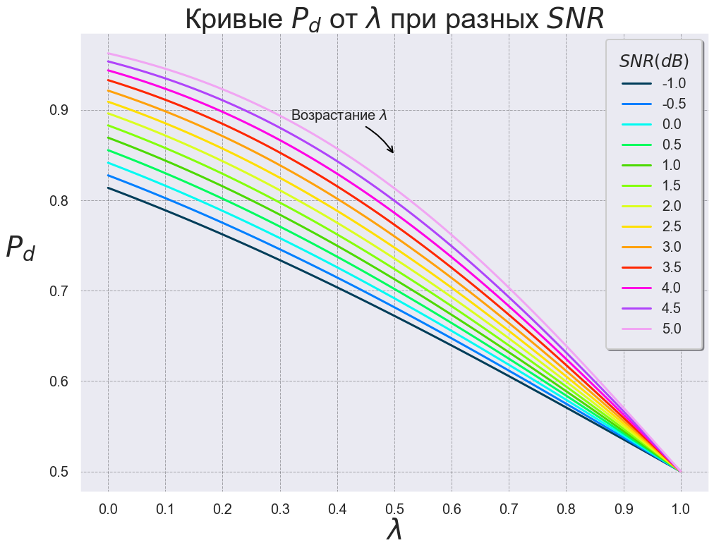

```python
fig, ax = plt.subplots(figsize=(16, 12))
sns.set_context('poster')
plt.title('Кривые $P_d$ от $\lambda$ при разных $SNR$', fontsize=40)
plt.xlabel('$\lambda$', fontsize=40)
plt.xticks(np.arange(0, 1.05, 0.1), fontsize=20)
plt.yticks(np.arange(0.5, 1.05, 0.1), fontsize=20)
plt.ylabel('$P_d$', fontsize=40, rotation=0, labelpad=40)
sns.lineplot(x='lambda', y='Pd', hue='SNR',
             data=data4, palette='gist_ncar', ax=ax)

ax.annotate("Возрастание $\lambda$", xy=(0.5, 0.85),  xycoords='data',
            xytext=(-10, 50), textcoords='offset points',
            size=20, ha='right',
            arrowprops=dict(arrowstyle="->", color='black',
                            connectionstyle="arc3,rad=-0.2"))
plt.grid(color='black', linestyle='--', linewidth=1, alpha=0.3)

plt.legend(fontsize='small', shadow=True, title='$SNR(dB)$',
           borderpad=0.9, fancybox=True);
```

Рис. 8 Кривые зависимости $P_d$ от $λ$ при различных значениях $SNR$.

$P_d$ достигает максимального значения при $λ=0$ и $SNR=5$. Но при таком низком пороге детектирования мы получаем:

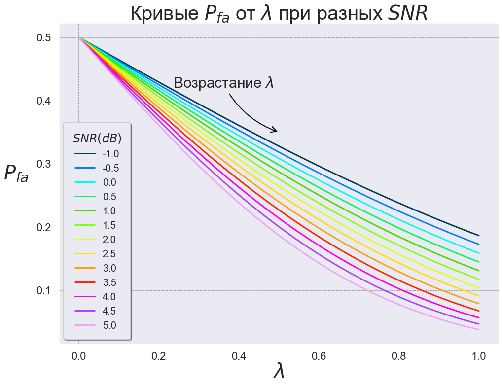

```python
fig, ax = plt.subplots(figsize=(16, 12))
sns.set_context('poster')
plt.title('Кривые $P_{fa}$ от $\lambda$ при разных $SNR$', fontsize=40)
plt.xlabel('$\lambda$', fontsize=40)
plt.ylabel('$P_{fa}$', fontsize=40, rotation=0, labelpad=40)
sns.lineplot(x='lambda', y='Pfa', hue='SNR',
             data=data4, palette='gist_ncar', ax=ax)

ax.annotate("Возрастание $\lambda$", xy=(0.5, 0.35),  xycoords='data',
            xytext=(-10, 90), textcoords='offset points',
            size=30, ha='right',
            arrowprops=dict(arrowstyle="->", color='black',
                            connectionstyle="arc3,rad=0.2"))
plt.grid(color='black', linestyle='--', linewidth=1, alpha=0.3)

plt.legend(fontsize='small', shadow=True, title='$SNR(dB)$',
           borderpad=0.9, fancybox=True);
```

Рис. 9 Кривые зависимости $P_{fa}$ от $λ$ при различных значениях $SNR$.

При $λ=0$ получается, что вероятность ложной тревоги равна $\frac{1}{2}$, так как определенный интеграл от условной плотности распределения $ \left.\frac{1}{\sqrt{2 \pi \sigma^{2}}} \int_{\lambda}^{+\infty} e^{-\frac{x^{2}}{2 \sigma^{2}}} d x\right|_{\lambda=\eta_{0}} $ считается от значения математического ожидания до $+∞$, что в точности равно $\frac{1}{2}$, в силу симметричности плотности нормального распределения.

Третье объясняется тем, что тангенс угла наклона $ROC$-кривой в некоторой ее точке равен значению плотностей $(6)$ от порога детектирования $λ$, необходимому для достижения $P_d$ и $P_{fa}$ в этой точке.

Пусть

$$ \tan \left(\alpha_{\lambda}\right):=\frac{\left(\frac{d P_{d}}{d \lambda}\right)}{\left(\frac{d P_{f a}}{d \lambda}\right)} \ \ ,(14) $$

тогда:

$$ \begin{aligned} &\tan \left(\alpha_{\lambda}\right)=\frac{\frac{d}{d \lambda}\left(\frac{1}{\sqrt{2 \pi \sigma^{2}}} \int_{\lambda}^{+\infty} e^{-\frac{(x-1)^{2}}{2 \sigma^{2}}} d x\right)}{\frac{d}{d \lambda}\left(\frac{1}{\sqrt{2 \pi \sigma^{2}}} \int_{\lambda}^{+\infty} e^{-\frac{x^{2}}{2 \sigma^{2}}} d x\right)}=\frac{-\frac{1}{\sqrt{2 \pi \sigma^{2}}} e^{-\frac{(\lambda-1)^{2}}{2 \sigma^{2}}}}{-\frac{1}{\sqrt{2 \pi \sigma^{2}}} e^{-\frac{(\lambda)^{2}}{2 \sigma^{2}}}}=\\ &=\frac{e^{-\frac{(\lambda-1)^{2}}{2 \sigma^{2}}}}{e^{-\frac{(\lambda)^{2}}{2 \sigma^{2}}}}=e^{-\frac{(\lambda-1)^{2}}{2 \sigma^{2}}+\frac{(\lambda)^{2}}{2 \sigma^{2}}}=e^{\frac{-\lambda^{2}+2 \lambda-1+\lambda^{2}}{2 \sigma^{2}}}=e^{\frac{2 \lambda-1}{2 \sigma^{2}}} \ \ \ (15) \end{aligned} $$

Исследуем функцию $(15)$ :

```python
# функция, которая возвращает значения Pfa и Pd по заданным 𝝈 и λ
def dif_roc_curve(sigma, lambda_):
    return (derivative(lambda x: 1 - norm.cdf(x/sigma), lambda_, dx=1e-10),
           derivative(lambda x: 1 - norm.cdf((x - 1)/sigma), lambda_, dx=1e-10))


data5 = []
for SNR in SNR_values:
    for lambda_ in [0, 0.5, 1]:
        dPfa, dPd = dif_roc_curve(snr_to_sigma(SNR), lambda_)
        Pfa, Pd = roc_curve(snr_to_sigma(SNR), lambda_)
        tan = dPd/dPfa
        for i in np.arange(0.01/tan, 0.2/tan, 0.01/tan):
            data5.append([tan*(i - Pfa) + Pd, i, str(SNR), lambda_])

data5 = pd.DataFrame(data5, columns=['y', 'x', 'SNR', 'lambda'])
```

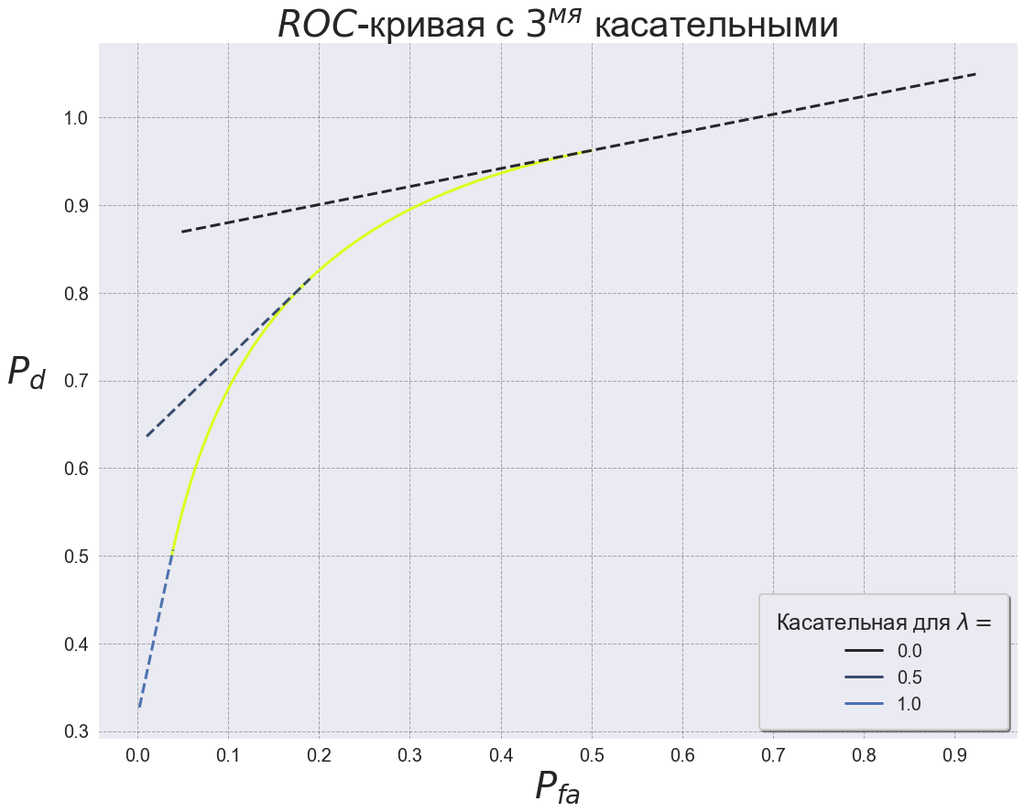

```python
fig, ax = plt.subplots(figsize=(18, 14))
sns.set_context('poster')
plt.title('$ROC$-кривая с $3^{мя}$ касательными', fontsize=40)
plt.xlabel('$P_{fa}$', fontsize=40)
plt.xticks(np.arange(0, 1.05, 0.1), fontsize=20)
plt.yticks(np.arange(0, 1.05, 0.1), fontsize=20)
plt.ylabel('$P_d$', fontsize=40, rotation=0, labelpad=40)
sns.lineplot(x='Pfa', y='Pd', hue='SNR', legend=False,
             data=data[data['SNR']  == '5.0'], palette='gist_ncar', ax=ax)
sns.lineplot(x='x', y='y', hue='lambda', linestyle='--',
             data=data5[data5['SNR']  == '5.0'],
             palette='dark:b', legend=True,  ax=ax)

plt.grid(color='black', linestyle='--', linewidth=1, alpha=0.3)

plt.legend(fontsize='small', shadow=True, title='Касательная для $\lambda=$',
           borderpad=0.9, fancybox=True, loc=4);
```

Рис. 10 $ROC$-кривая $SNR=5$ с тремя касательными в точках. $$ \left(P_{f a}(0), P_{d}(0)\right),\left(P_{f a}(0.5), P_{d}(0.5)\right),\left(P_{f a}(1), P_{d}(1)\right) $$

# Вывод

В ходе исследования были построены множество $ROC$-кривых на основе аналитического выражения $(12)$. Были также получены свойства $ROC$-кривых на основе графиков и аналитических выражений. То, каким образом будет выглядеть характеристика рабочего приемника, зависит от значения $SNR$, из которого однозначно определяется значение $σ$. Также область, в которой определена $ROC$-кривая, зависит от диапазона $λ$, который был ограничен диапазоном от $0$ до $1$.